# VID - Projet

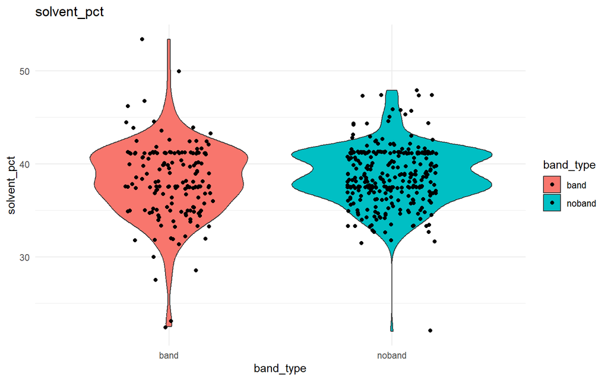

```r
ggplot(cylinder4, aes_string(x="band_type", y="solvent_pct", fill="band_type")) +
       geom_violin() +
       geom_jitter(aes(color=band_type), width=0.2, height = 0.1, color="black") +
       labs(title="solvent_pct", y="solvent_pct") +
  theme_minimal()
```

Pour “ESA_voltage”, il semblerait que des valeurs entre 5 et 12 produirait moins de bandes.

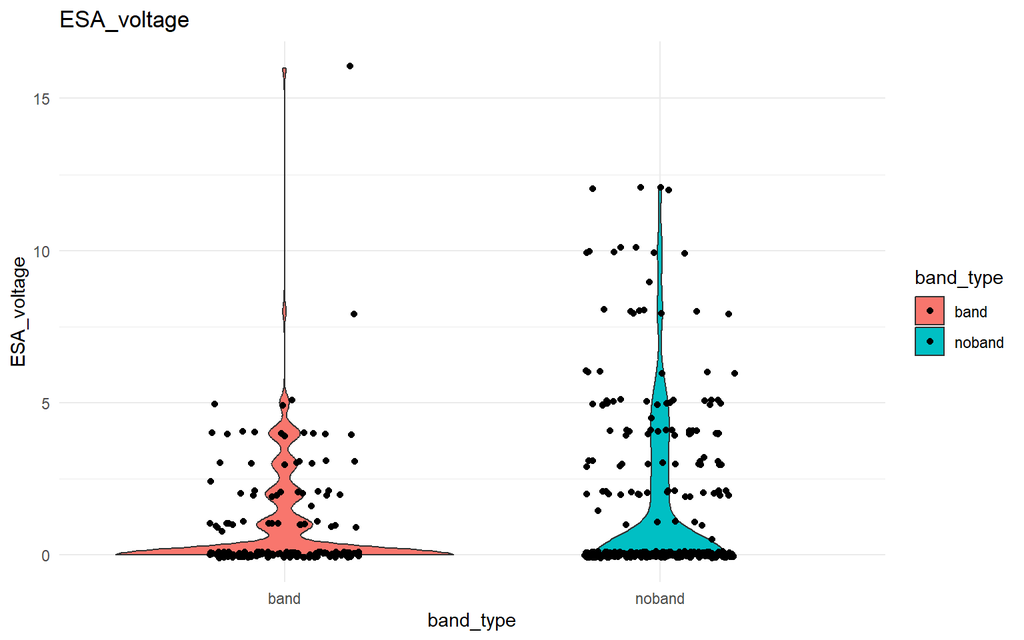

```r
ggplot(cylinder4, aes_string(x="band_type", y="ESA_voltage", fill="band_type")) +
       geom_violin() +
       geom_jitter(aes(color=band_type), width=0.2, height = 0.1, color="black") +
       labs(title="ESA_voltage", y="ESA_voltage") +
  theme_minimal()
```

Pour la valeur de durcisseur utilisé, on peut dire qu’une quantité de 1 à tendance à produire plus de bandes. Le reste produirait moins de bande.

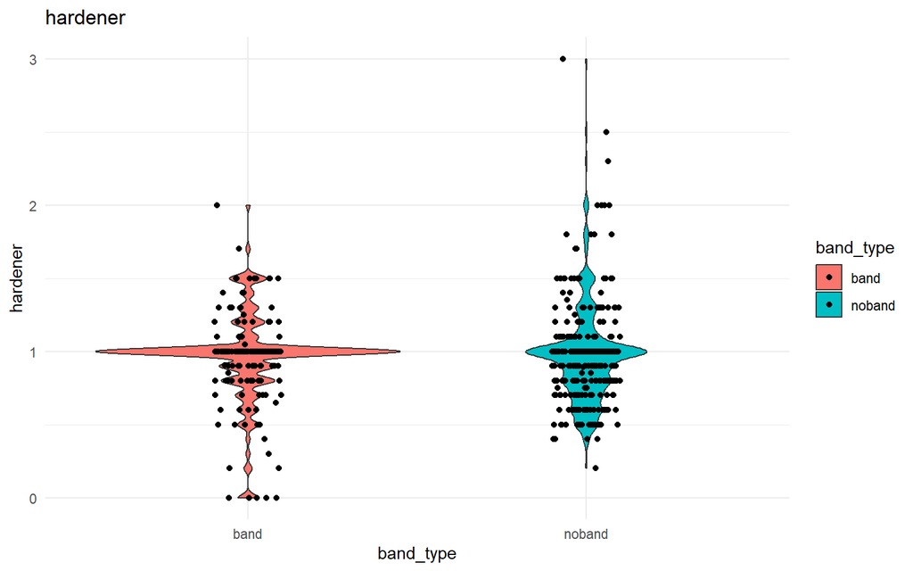

```r
ggplot(cylinder4, aes_string(x="band_type", y="hardener", fill="band_type")) +
       geom_violin() +
       geom_jitter(aes(color=band_type), width=0.1, height = 0.0, color="black") +
       labs(title="hardener", y="hardener") +
  theme_minimal()
```

Pour la densité, le graphique démontre qu’une densité de 35 ou supérieur à 40 produirait moins de bande.

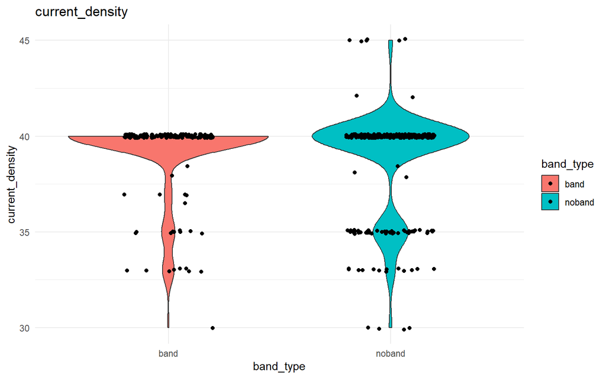

```r
ggplot(cylinder4, aes_string(x="band_type", y="current_density", fill="band_type")) +
       geom_violin() +
       geom_jitter(aes(color=band_type), width=0.2, height = 0.1, color="black") +
       labs(title="current_density", y="current_density") +
  theme_minimal()
```

Pour le ratio d’espace d’anode, on peut dire qu’il serait mieux d’utiliser un ratio inférieur à 94 ou égal à 104 environ.

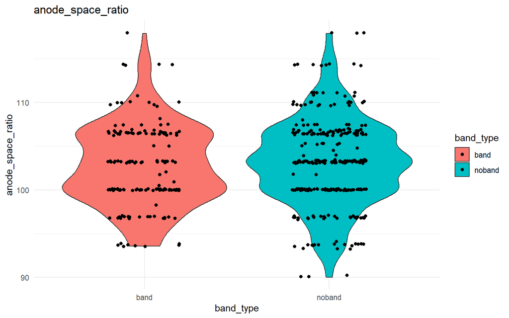

```r
ggplot(cylinder4, aes_string(x="band_type", y="anode_space_ratio", fill="band_type")) +
       geom_violin() +
       geom_jitter(aes(color=band_type), width=0.2, height = 0.1, color="black") +
       labs(title="anode_space_ratio", y="anode_space_ratio") +
  theme_minimal()
```

## 4.2 Arbre de décision

Pour cette partie, nous allons utiliser les arbres de décisions pour tenter de déterminer les variables les plus importantes.

```r
set.seed(010666)
cylinder.ct <- rpart(formula = band_type~., method = "class", data = cylinder4, cp = 0.00001)
```

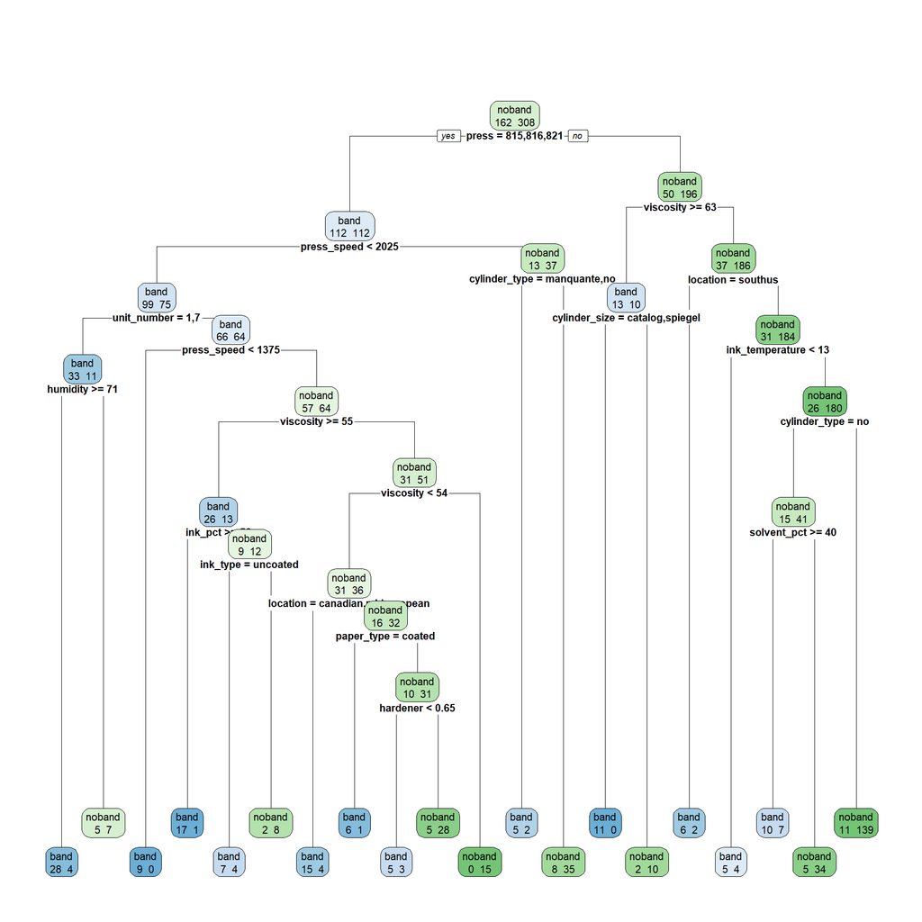

```r
rpart.plot(cylinder.ct, main="", cex=0.7, extra = 1)
```

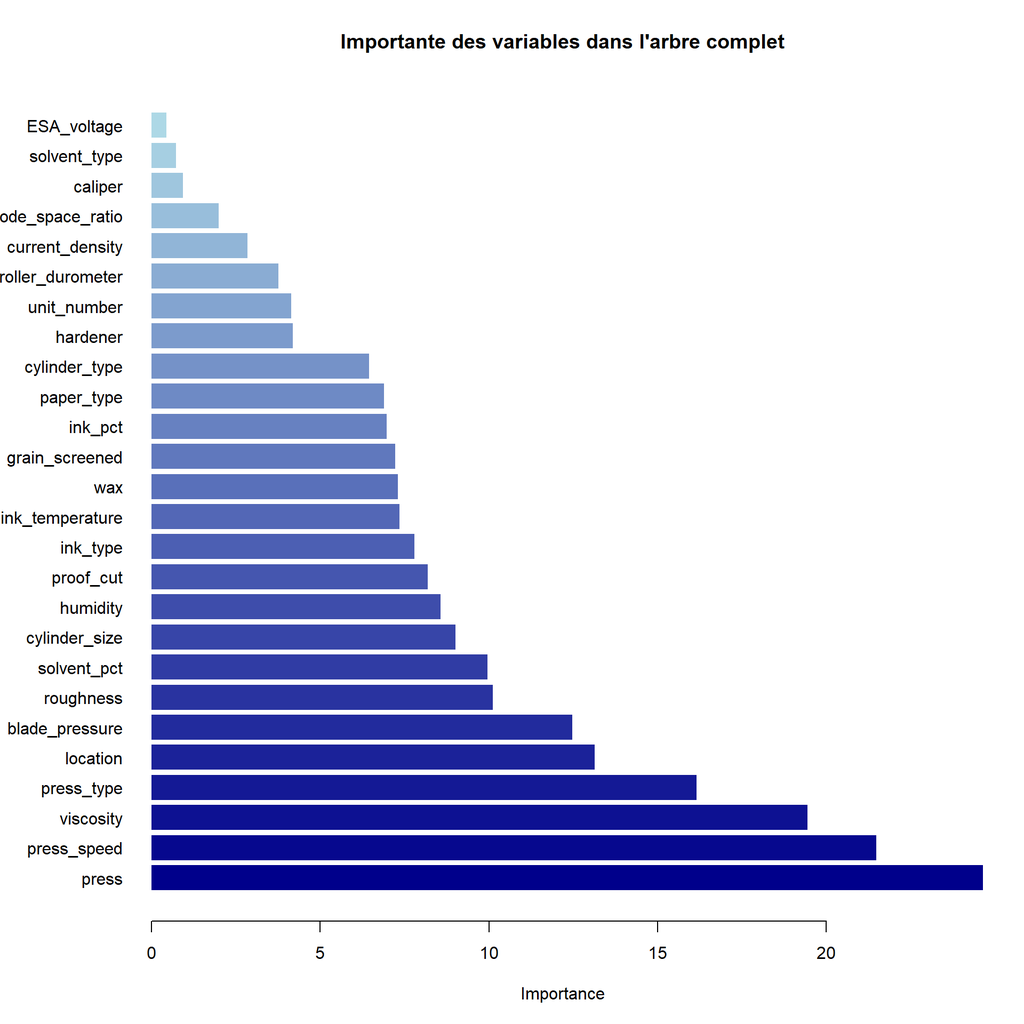

```r
var_importance <- cylinder.ct$variable.importance
sorted_importance <- var_importance[order(var_importance, decreasing = TRUE)]
bar_colors <- colorRampPalette(c("darkblue", "lightblue"))(length(sorted_importance))

par(mar = c(5, 7, 4, 2))

barplot(sorted_importance, horiz = TRUE, las = 1,
        main = "Importante des variables dans l'arbre complet",
        xlab = "Importance", col = bar_colors, border = NA)
```

Cette fois-ci, il s’agit de l’arbre de classification optimal. Celui-ci a été obtenu en utilisant la règle du “un écart type”. On remarque que celui-ci a bel et bien un nombre de division inférieur au précédent. On remarque que les variables importantes sont toujours similaires à l’arbre complet.

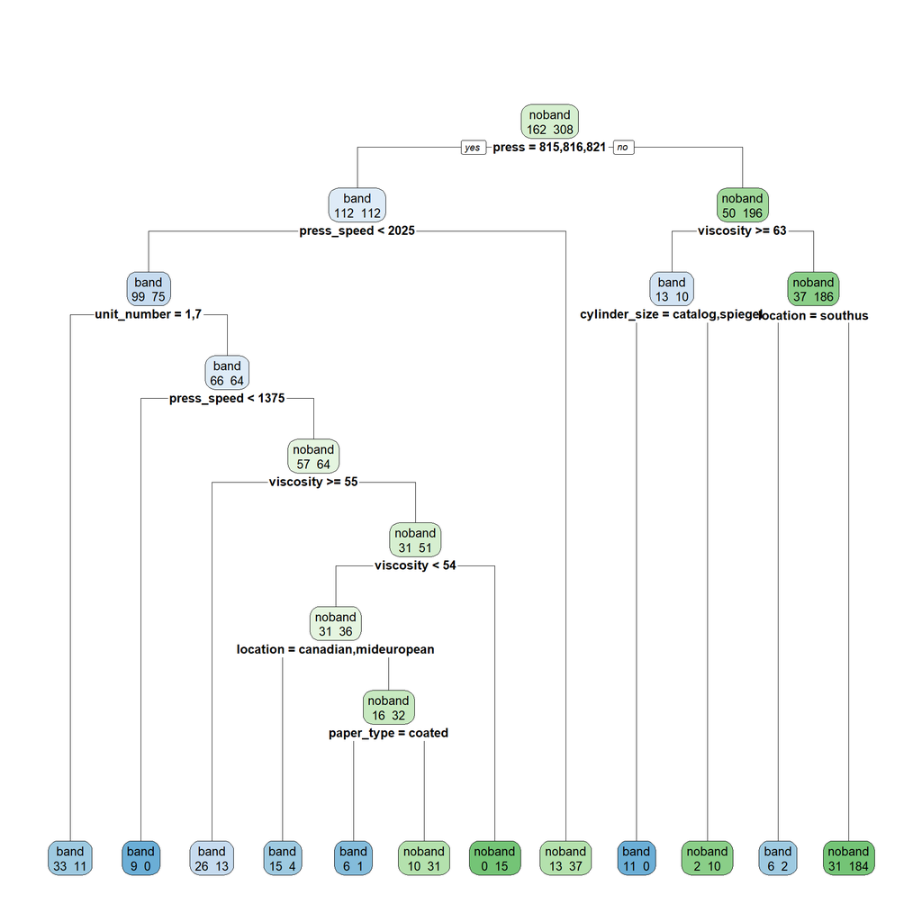

```r
ct<-cylinder.ct$cptable
opt<-which.min(cylinder.ct$cptable[,"xerror"])
r<-ct[, 4][opt] + ct[, 5][opt]
rmin<-min(seq(1:dim(ct)[1])[ct[, 4] < r])
ct0<-ct[rmin,1]

cylinder.prune <- prune(cylinder.ct, cp = ct0)

rpart.plot(cylinder.prune, main="", cex=0.8, extra=1)
```

Voici à nouveau le graphique sur l’importance des variables dans l’arbre optimal cette fois-ci. Dans le top 5 des variables qui influent le plus sur l’apparition ou non de bandes, on remarque que seul blade_pressure et location ont échangés de positions.

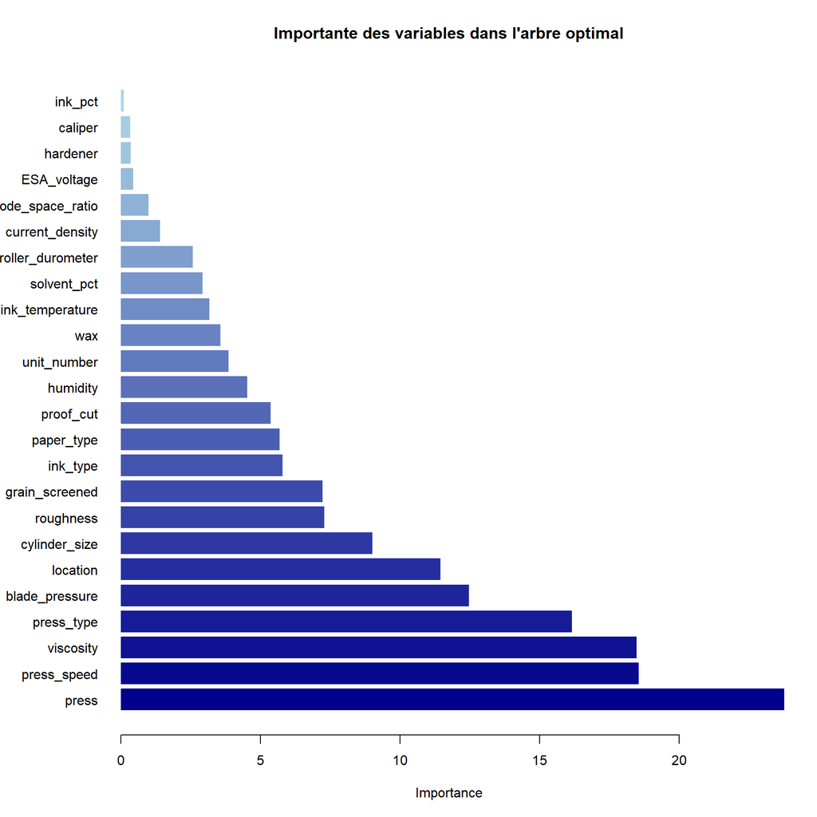

```r
var_importance <- cylinder.prune$variable.importance
sorted_importance <- var_importance[order(var_importance, decreasing = TRUE)]
bar_colors <- colorRampPalette(c("darkblue", "lightblue"))(length(sorted_importance))

par(mar = c(5, 7, 4, 2))

barplot(sorted_importance, horiz = TRUE, las = 1,
        main = "Importante des variables dans l'arbre optimal",
        xlab = "Importance", col = bar_colors, border = NA)
```

On peut conclure qu’en utilisant l’arbre de classification, les variables les plus importantes sont : press, press_speed, viscosity, press_type et location.

Cependant, ces arbres de classification se concentrent beaucoup sur les presses utilisées. Or, il n’est pas forcément possible d’utiliser uniquement les meilleures presses. Il serait donc préférable de trouver des réglages pour chaque presse afin de minimiser les défauts de bandes.

Pour cela, nous allons créer 2 nouveaux arbres de classifications où le premier sera composé uniquement des presses produisant plus de défauts et le deuxième sera composé des autres presses. Cela nous permettra de généraliser un peu plus les différents paramètres à utiliser dans chacun des cas.

```r
good_press <- subset(cylinder4, !press %in% c(815, 816, 821))
bad_press <- subset(cylinder4, press %in% c(815, 816, 821))
```

Voici l’arbre de classification optimal pour les presses qui produisent moins de bandes. On remarque que celui-ci n’est pas très complexe et que les 3 variables utilisées sont viscosity, cylinder_size et location.

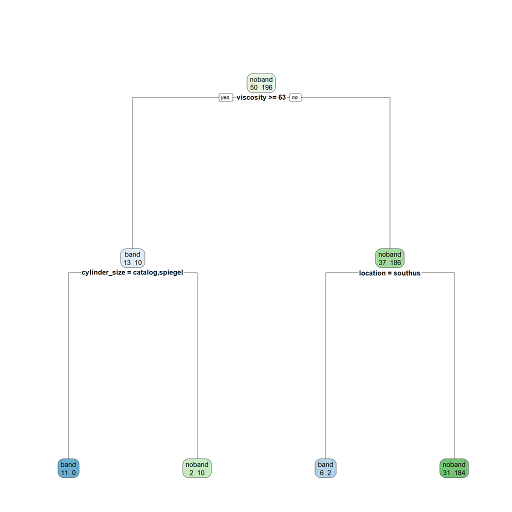

```r
good_press.ct <- rpart(formula = band_type~., method = "class", data = good_press, cp = 0.026667)
rpart.plot(good_press.ct, main="", cex=0.8, extra=1)
```

Voici maintenant l’arbre de classification optimal pour les presses 815, 816, 821. Il s’agit des presses produisant le plus de défaut de bandes. On remarque que la vitesse de la presse est très importante, de même que la viscosité et le numéro de l’unité.

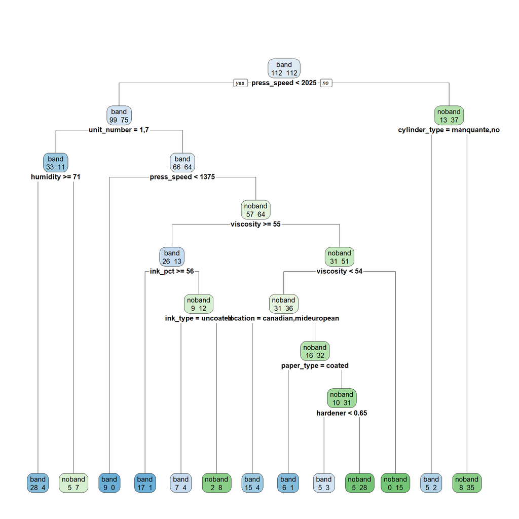

```r
bad_press.ct <- rpart(formula = band_type~., method = "class", data = bad_press, cp = 0.001)

ct<-bad_press.ct$cptable
opt<-which.min(bad_press.ct$cptable[,"xerror"])
r<-ct[, 4][opt] + ct[, 5][opt]
rmin<-min(seq(1:dim(ct)[1])[ct[, 4] < r])
ct0<-ct[rmin,1]

bad_pres.prune <- prune(bad_press.ct, cp = ct0)

rpart.plot(bad_pres.prune, main="", cex=0.8, extra=1)
```

On peut aussi afficher à nouveau le tableau d’importance et on remarque quelques différences par rapport à l’arbre. On remarque que les variables les plus importantes sont la vitesse de la presse, la viscosité ainsi que la localisation.

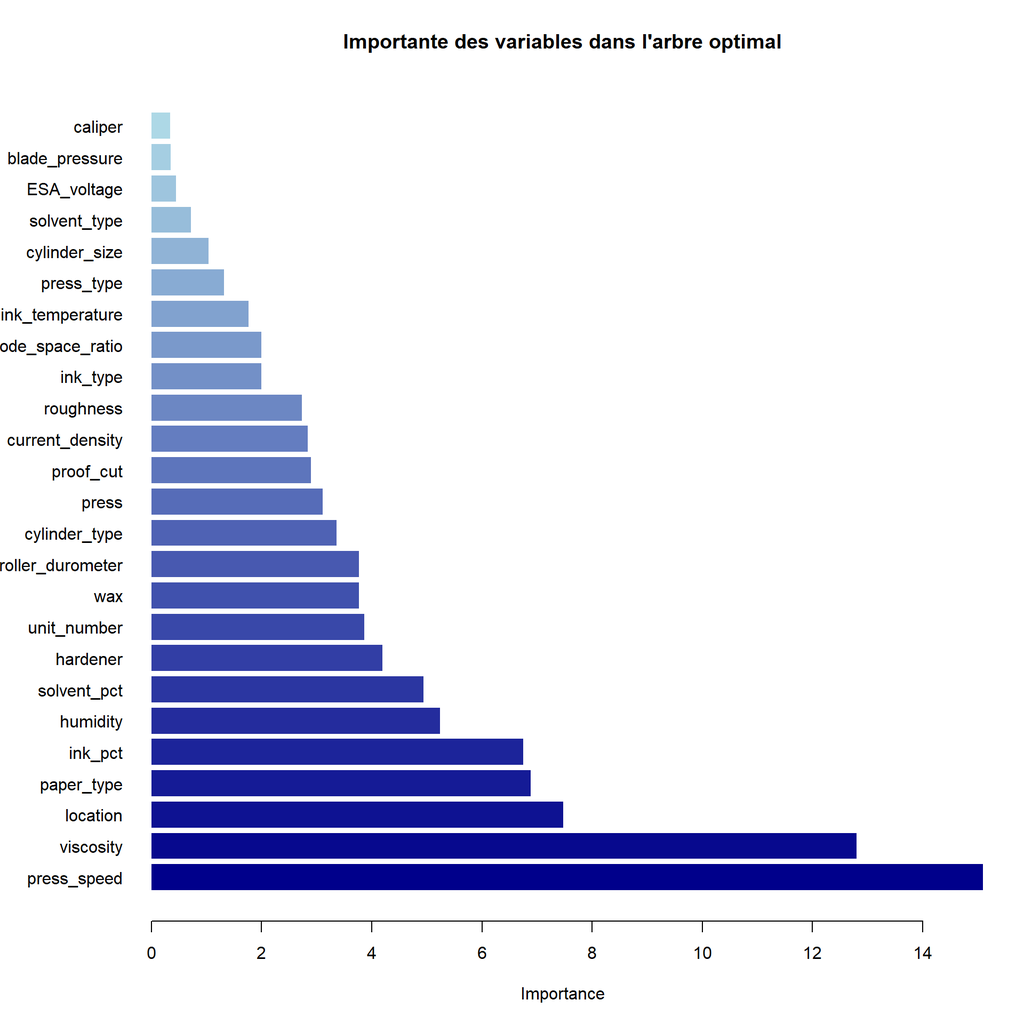

```r
var_importance <- bad_pres.prune$variable.importance
sorted_importance <- var_importance[order(var_importance, decreasing = TRUE)]
bar_colors <- colorRampPalette(c("darkblue", "lightblue"))(length(sorted_importance))

par(mar = c(5, 7, 4, 2))

barplot(sorted_importance, horiz = TRUE, las = 1,
        main = "Importante des variables dans l'arbre optimal",
        xlab = "Importance", col = bar_colors, border = NA)
```

Pour aller encore plus loin, nous pourrions créer un arbre de classification pour chaque presse afin d’identifier les meilleurs paramètres à utiliser en fonction de chaque presse mais cela ne sera pas réaliser dans ce projet.

## 4.3 RandomForest

Afin d’améliorer notre prédiction, nous allons utiliser la librairie randomForest. La forêt aléatoire est une méthode qui combine plusieurs arbres de décision où chaque arbre est construit avec un échantillon aléatoire des données d’entrainement. La prédiction finale est une combinaison des prédictions individuelles de chaque arbre de décision.

```r
rf_cylinder <- randomForest(as.formula(paste("band_type", "~ .")), data = cylinder4, importance = TRUE)
```

Voici l’importance des variables déduites par l’algorithme des forêts aléatoires. On remarque à peu près que les variables jugées comme les plus importantes sont à nouveau les mêmes que celles prédites par les arbres de classification. A savoir “press”, “press_type”, “press_speed”, “viscosity” et une nouvelle variable “ink_type”.

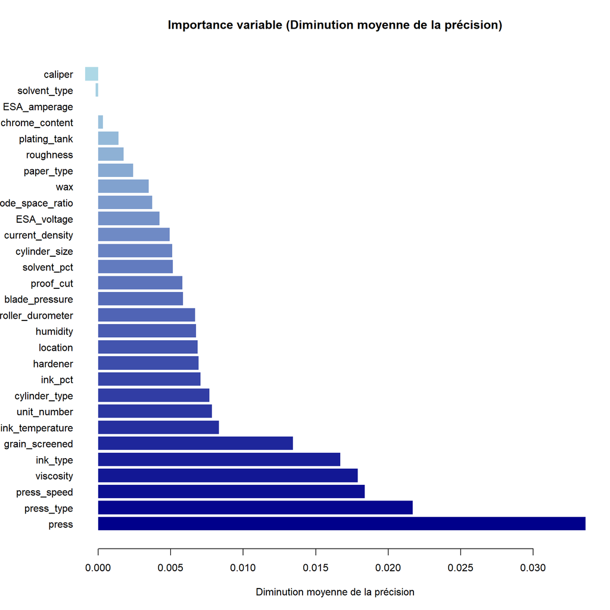

```r
importance_values <- rf_cylinder$importance

sorted_importance <- importance_values[order(importance_values[, "MeanDecreaseAccuracy"], decreasing = TRUE), "MeanDecreaseAccuracy"]

bar_colors <- colorRampPalette(c("darkblue", "lightblue"))(length(sorted_importance))

par(mar = c(5, 7, 4, 2))

barplot(sorted_importance, horiz = TRUE, las = 1,
        main = "Importance variable (Diminution moyenne de la précision)",
        xlab = "Diminution moyenne de la précision", col = bar_colors, border = NA)
```

# 5 Conclusion

Pour conclure, notre mission dans ce projet était d’améliorer la qualité des impressions rotogravures en détectant quelles variables étaient les plus importantes pour tenter de réduire le problème des défauts de bandes survenant à l’impression et tenter de réduire le nombre de prédicteurs pour des performances plus efficaces.

Pour réaliser cela, nous avions à disposition un jeu de données comportant 540 observations, 39 variables explicatives et une variable de réponse. Nous avons utilisé la méthodologie CRISP-DM pour réaliser les différentes étapes. Celles-ci sont :

- Compréhension du problème : Premièrement, nous avons dû comprendre le problème en profondeur. L’impression par rotogravure n’étant pas dans notre domaine de compétence, il a fallu se renseigner sur ce type d’impression et comprendre comment les défauts de bande apparaissaient.
- Compréhension des données : Après cela, nous avons dû comprendre les données, cela a impliqué l’affichage de tableau et de graphiques pour visualiser le jeu de données et ses particularités. On a par exemple remarqué un gros bruit dans le jeu de données sur les dernières observations.
- Préparation des données : Une fois la compréhension des données effectuées, nous avons dû préparer les données afin de pouvoir les exploiter correctement. Cette étape inclut la transformation des attributs textuels, la transformation des attributs en facteurs, la suppression du bruit, le traitement des valeurs aberrantes et manquantes ainsi que la suppression des attributs non pertinents.
- Sélection des attributs : La dernière étape a été de sélectionner les attributs. Pour cela, 3 méthodes ont été utilisées. Premièrement la visualisation des variables à l’aide de graphiques nous ont permis de visualiser quelles variables affectaient le plus les défauts de bandes. Deuxièmement, nous avons utilisé les arbres de décisions pour visualiser l’importance des variables ainsi que les intervalles et catégories à privilégier pour éviter les bandes. Dernière méthode, l’utilisation de forêt aléatoire nous permettant de tester plusieurs arbres sur des partitions de jeu de données différentes.

Lors des prochaines impressions, une attention particulière devra donc être mise sur ces variables pour éviter les défauts de bandes.